# Figuren-overzicht — *De regressieve ruggengraat*

## H11

`h11_decompositie.png`

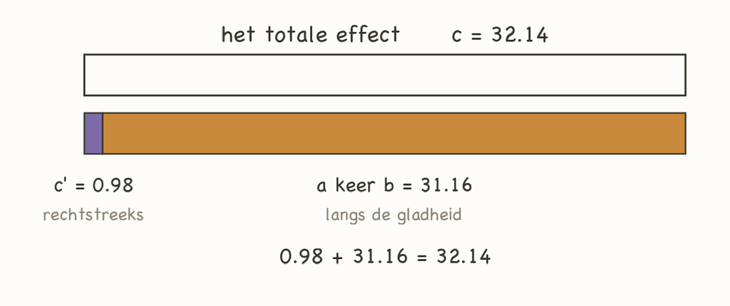

`h11_estafette.png`

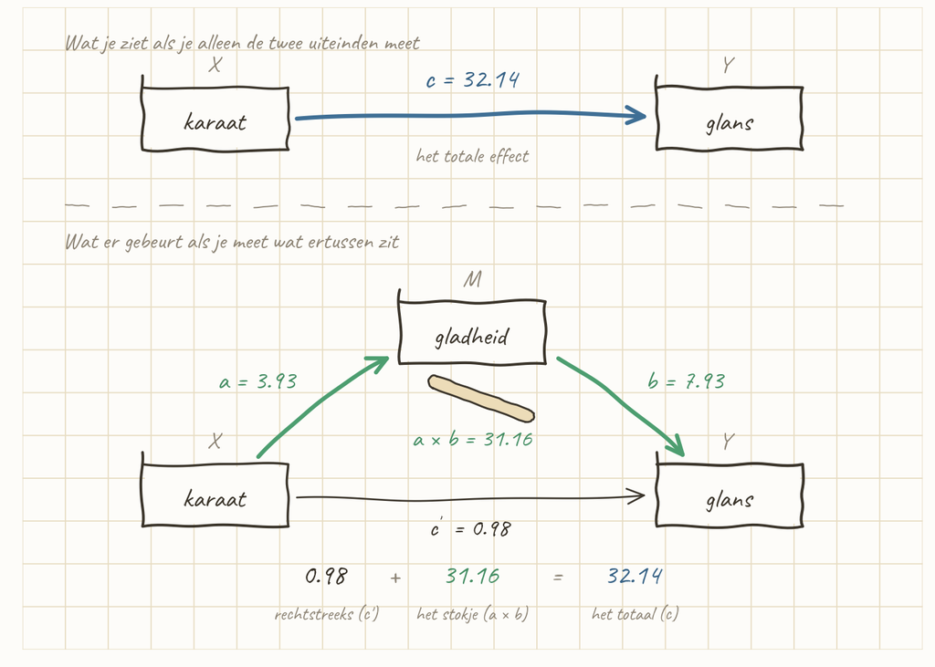

`h11_muur.png`

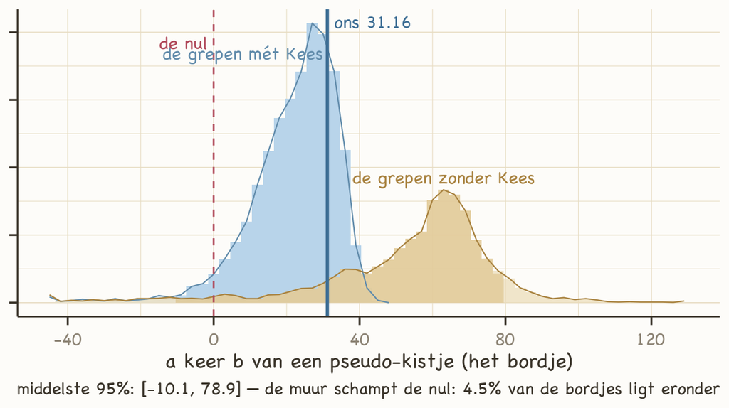

## H12

`h12_afgeknepen.png`

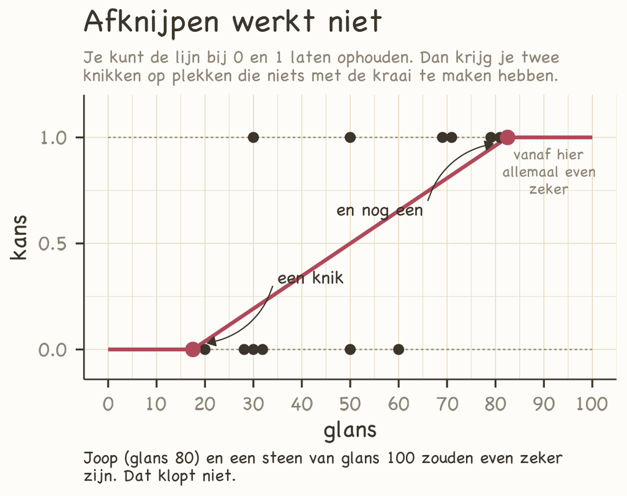

`h12_drie_stappen.png`

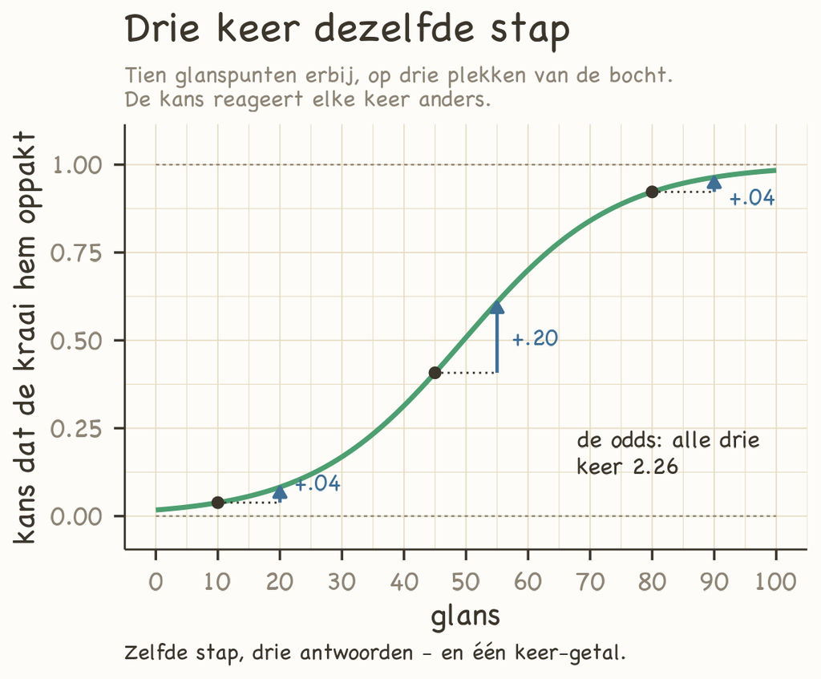

`h12_drie_vormen.png`

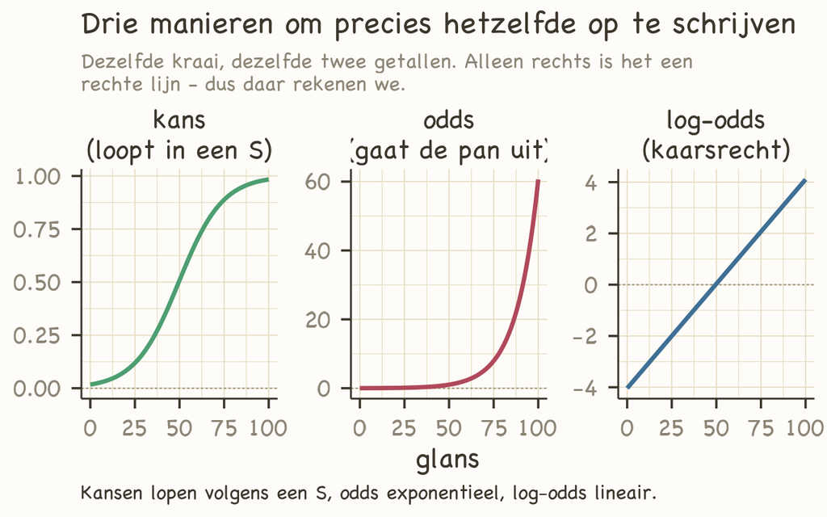

`h12_lijn_stukloopt.png`

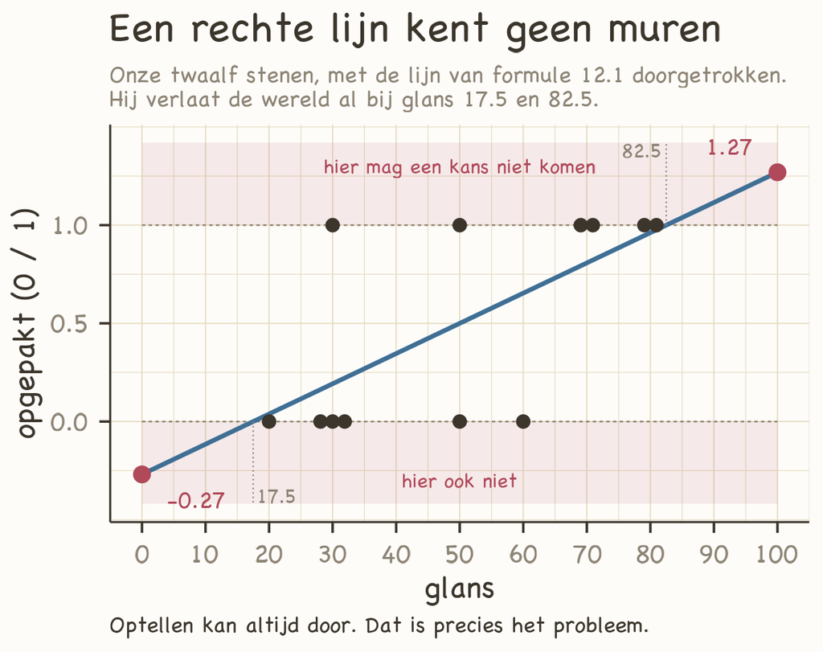

`h12_s_bocht.png`

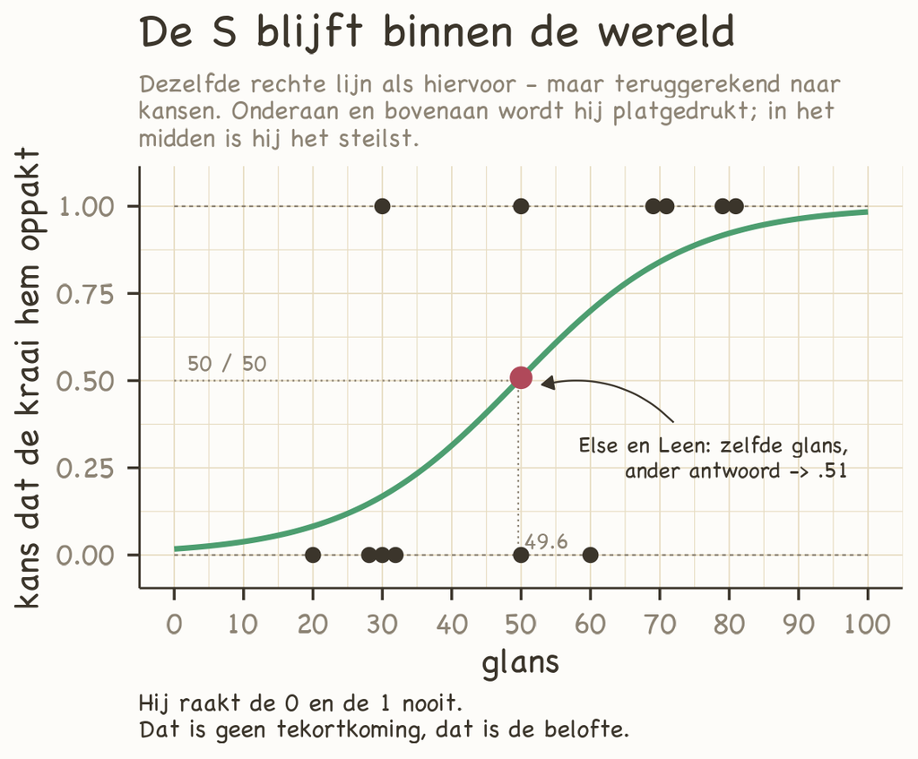

## OVERIG

`_uit_decompositie/dec_1_totaal.png`

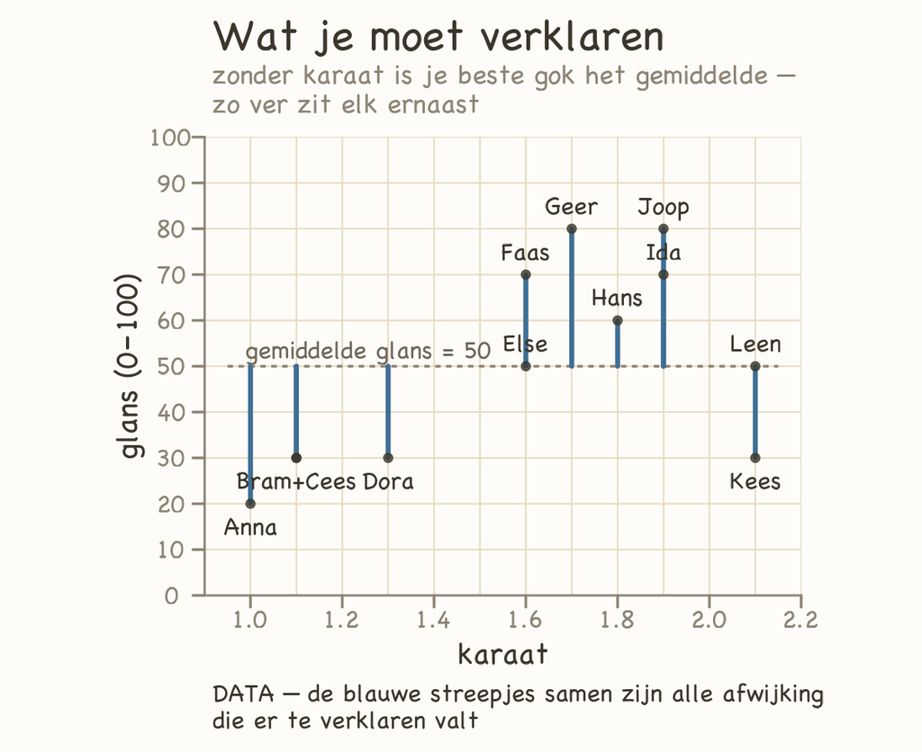

`_uit_decompositie/dec_3_splitsing.png`

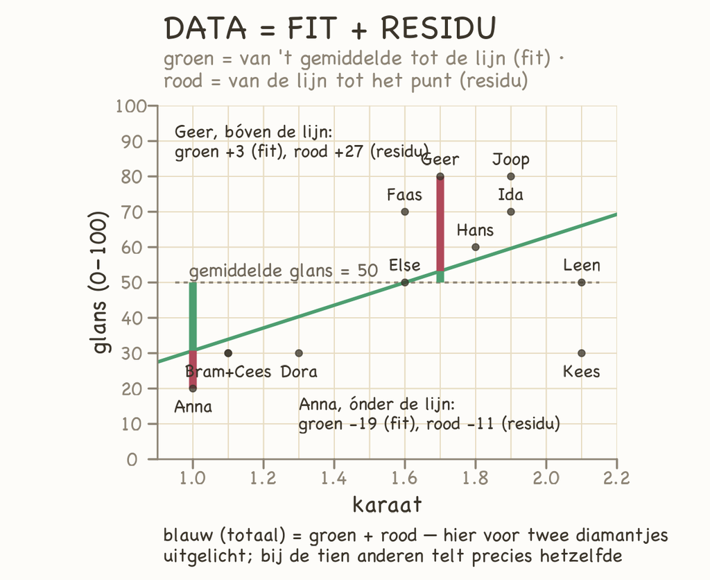

`_uit_decompositie/dec_strip.png`

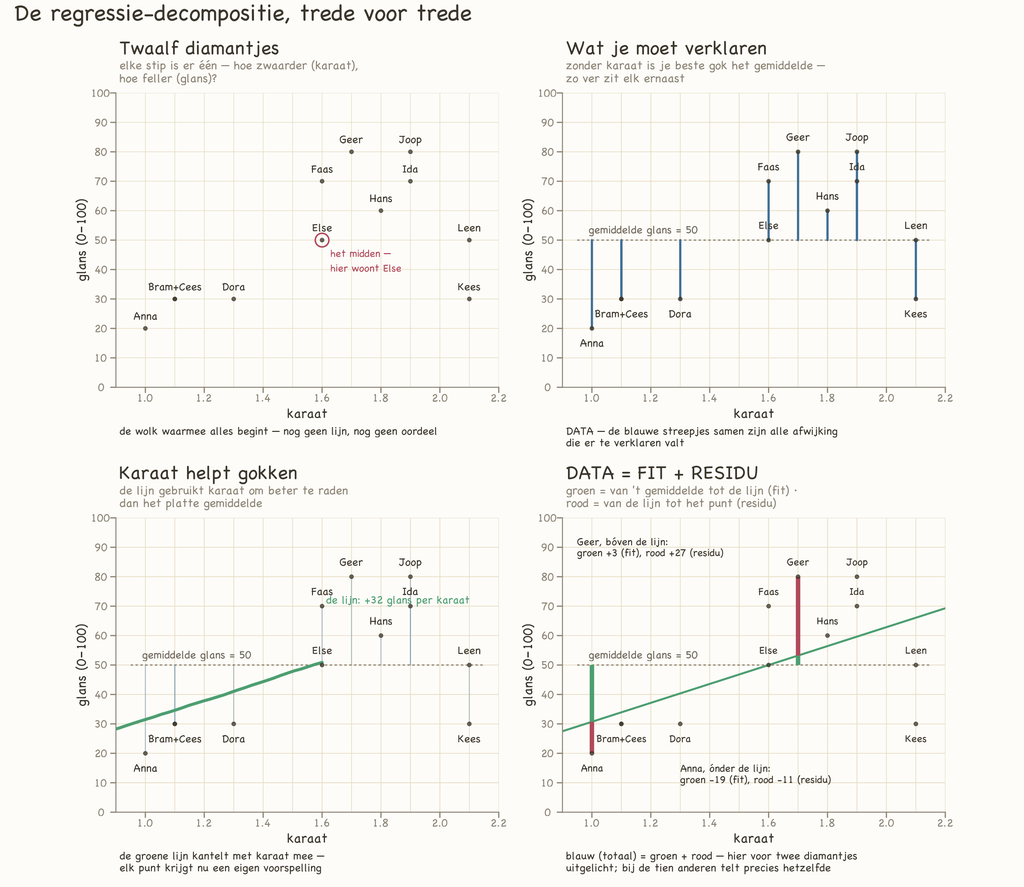

`_uit_decompositie/h1_wolk.png`

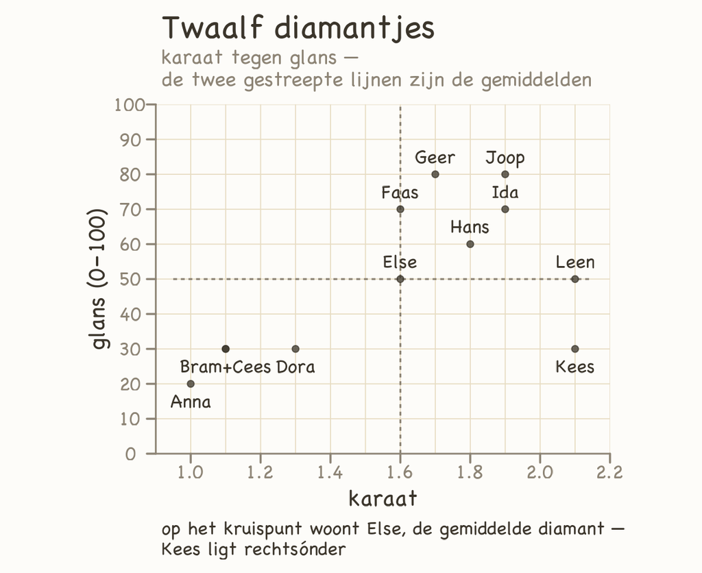

*Niet getoond — 8 wees/proef-PNG (niet in het boek ingebed): `_archief/h2_scheef.png`, `_uit_decompositie/dec_0_wolk.png`, `_uit_decompositie/dec_2_lijn.png`, `h3_verdeling_1_ton.png`, `h3_verdeling_2_kistje.png`, `h3_verdeling_3_muur.png`, `h8_noemers.png`, `poppetje_proef_laaglaag.png`. Gearchiveerde figuren: `_archief/`.*